# HDAT9700: Assessment 2 - Chapters 3-5

Multilevel modelling

Maggie Burmeister

12/10/2024

## 0.1 Student declaration

*Instructions: Indicate that you understand and agree with the following three statements by typing an x in the square brackets below, e.g. [x].*

I declare that this assessment item is my own work, except where acknowledged, and has not been submitted for academic credit elsewhere or previously, or produced independently of this course (e.g. for a third party such as your place of employment) and acknowledge that the assessor of this item may, for the purpose of assessing this item: (i) Reproduce this assessment item and provide a copy to another member of the University; and/or (ii) Communicate a copy of this assessment item to a plagiarism checking service (which may then retain a copy of the assessment item on its database for the purpose of future plagiarism checking).

- I understand and agree

I certify that I have read and understood the University Rules in respect of Student Academic Misconduct.

- I understand and agree

I have a backup copy of the assessment.

- I understand and agree

## 0.2 Statement on the use of generative AI

*Instructions: If you have used Generative AI tools (e.g. ChatGPT, copilot, etc) to help complete this assessment, please state the details here. Your statement should include (i) the name of tool used; (ii) sections or questions that were answered with the help of generative AI; (iii) How generative AI was used. For example you might write “I used Microsoft Copilot to generate template R code for questions 1 and 2, and to help draft my written response to question 4.” If you have not used Generative AI to help complete your assessment, please state this.*

I used ChatGPT to generate template R code for question 2 in section 2. The rest of the assignment I read lecture notes, practical, ideas from HDAT 9600 and 9800 for visualization.

# 1 Section 1

## 1.1 Question 1: What is the hierarchical data structure for this analysis?

The hierarchical data structure for this analysis on this paper, I think there is two levels of hierarchy. Patient level: from the paper, we can see that they collected patient data including demographic characteristics (sex, age, education, and annual family income), clinical characteristic (cancer type, cancer stage, self-reported health status, and length of stay), satisfaction score across various aspects of health. At hospital level,data was collected based on five aspects: administrative process, hospital environment, medical care, symptom management and overall satisfaction, these information allow for the exploration of how hospital-level factors affect patient satisfaction outcome across hospitals.

## 1.2 Question 2: With reference to appropriate Figure(s) or Table(s), discuss whether the national-level hospitals are performing better or worse compared to provincial-level hospitals for the five satisfaction measures, having accounted for case-mix.

The effect of mix-case adjustment reveals that national level hospitals are performing better than provincial level hospitals in general across five satisfaction measures: administrative process, hospital environment, medical care, symptom management, and overall satisfaction. Based on Figure 2 (caterpillar plots) we can analyse five measurements: 1. Medical care: for medical care, national level hospitals scored higher in patient satisfaction. 2. Administrative Process: both national and provincial hospitals showed lower satisfaction in the administrative process even after the adjustment. However, national-level hospital still manage this measure better than provincial hospitals. 3.Hospital Environment: for this measure, only 11 hospitals above O for satisfaction from patients. National-level hospitals are still performing better than provincial hospitals. 4.Symptom Management: this aspect received lower scores overall with a more significant performance gap between national and provincial hospitals. 5. Overall Satisfaction: National-level hospitals also perform well in this aspect which reflect higher patient satisfaction across multiple facets of care.

# 2 Section 2

## 2.1 Question 1: EDA dataset

### 2.1.1 Load necessary libraries

|  | id | status | area | sex | age | los | readmission | satisfaction |
| --- | --- | --- | --- | --- | --- | --- | --- | --- |
| 1 | 1001 | private | regional | F | 68 | 1 | No | 51 |
| 2 | 1001 | private | regional | F | 73 | 6 | No | 61 |
| 3 | 1001 | private | regional | F | 80 | 11 | No | 82 |
| 4 | 1001 | private | regional | M | 84 | 7 | No | 62 |
| 5 | 1001 | private | regional | F | 46 | 4 | No | 57 |
| 6 | 1001 | private | regional | M | 85 | 2 | Yes | 60 |

```
##        id           status           area      sex           age
##  Min.   :1001   private:1441   regional:2752   F:3826   Min.   :22.00
##  1st Qu.:1011   public :6249   remote  : 870   M:3864   1st Qu.:64.00
##  Median :1021                  urban   :4068            Median :72.00
##  Mean   :1021                                           Mean   :70.94
##  3rd Qu.:1033                                           3rd Qu.:80.00
##  Max.   :1040                                           Max.   :98.00
##       los         readmission         satisfaction
##  Min.   : 1.000   Length:7690        Min.   :16.00
##  1st Qu.: 2.000   Class :character   1st Qu.:42.00
##  Median : 3.000   Mode  :character   Median :50.00
##  Mean   : 4.064                      Mean   :50.58
##  3rd Qu.: 5.000                      3rd Qu.:59.00
##  Max.   :25.000                      Max.   :96.00
```

```
## .
##
##  8  Variables      7690  Observations
## --------------------------------------------------------------------------------
## id
##        n  missing distinct     Info     Mean      Gmd      .05      .10
##     7690        0       40    0.999     1021    13.91     1002     1004
##      .25      .50      .75      .90      .95
##     1011     1021     1033     1037     1039
##
## lowest : 1001 1002 1003 1004 1005, highest: 1036 1037 1038 1039 1040
## --------------------------------------------------------------------------------
## status
##        n  missing distinct
##     7690        0        2
##
## Value      private  public
## Frequency     1441    6249
## Proportion   0.187   0.813
## --------------------------------------------------------------------------------
## area
##        n  missing distinct
##     7690        0        3
##
## Value      regional   remote    urban
## Frequency      2752      870     4068
## Proportion    0.358    0.113    0.529
## --------------------------------------------------------------------------------
## sex
##        n  missing distinct
##     7690        0        2
##
## Value          F     M
## Frequency   3826  3864
## Proportion 0.498 0.502
## --------------------------------------------------------------------------------
## age
##        n  missing distinct     Info     Mean      Gmd      .05      .10
##     7690        0       70    0.999    70.94    13.24       50       55
##      .25      .50      .75      .90      .95
```

[output cut: 13 more lines]

```
##        n  missing distinct
##     7690        0        2
##
## Value         No   Yes
## Frequency   5801  1889
## Proportion 0.754 0.246
## --------------------------------------------------------------------------------
## satisfaction
##        n  missing distinct     Info     Mean      Gmd      .05      .10
##     7690        0       80    0.999    50.58    14.29       31       35
##      .25      .50      .75      .90      .95
##       42       50       59       68       73
##
## lowest : 16 18 19 20 21, highest: 92 93 94 95 96
## --------------------------------------------------------------------------------
```

```
##       age             los          satisfaction
##  Min.   :22.00   Min.   : 1.000   Min.   :16.00
##  1st Qu.:64.00   1st Qu.: 2.000   1st Qu.:42.00
##  Median :72.00   Median : 3.000   Median :50.00
##  Mean   :70.94   Mean   : 4.064   Mean   :50.58
##  3rd Qu.:80.00   3rd Qu.: 5.000   3rd Qu.:59.00
##  Max.   :98.00   Max.   :25.000   Max.   :96.00
```

### 2.1.2 Distributions for Num variables

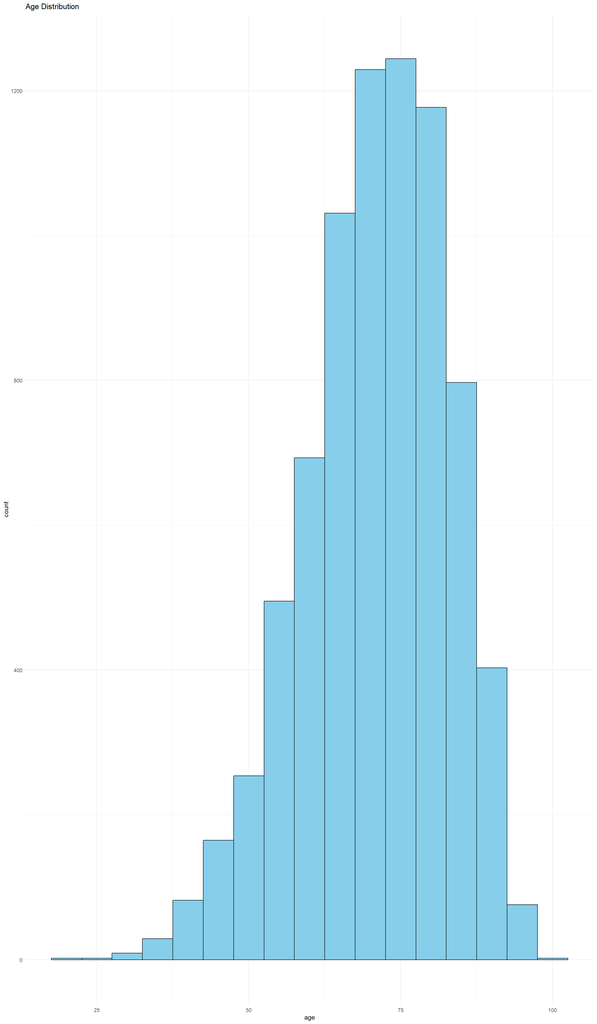

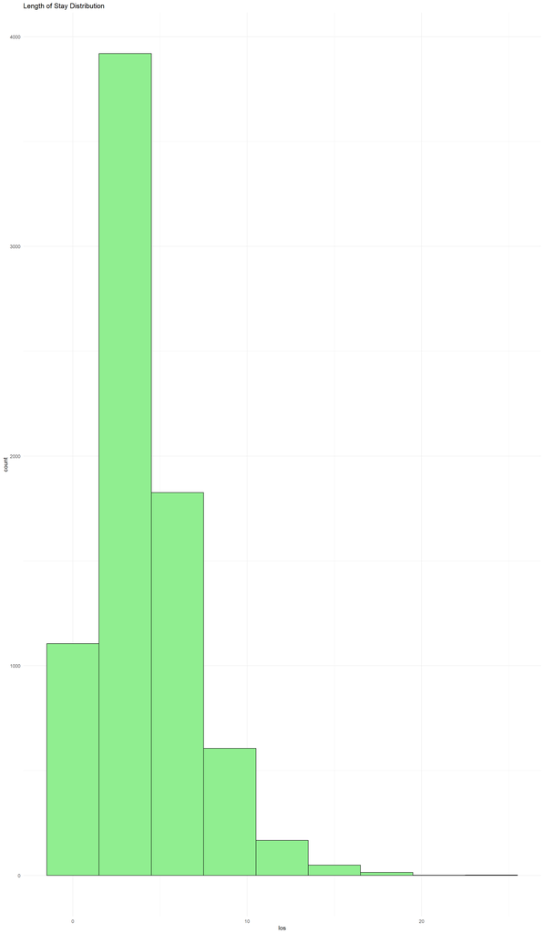

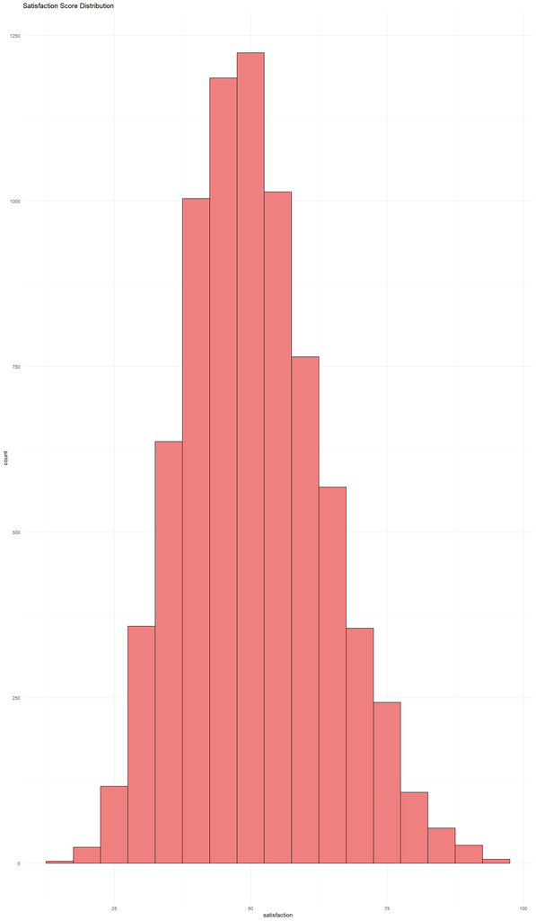

By the look through three graphs above, we can see age has skewed left distribution, LOS has skewed right distribution. Only satisfaction score has pretty normal distribution.

### 2.1.3 Boxplot for Num variables

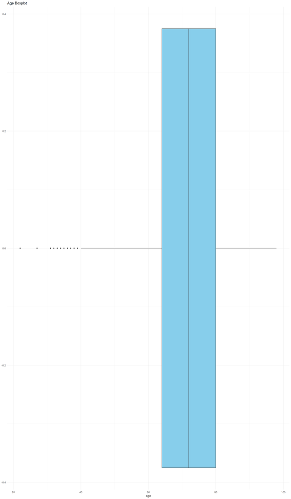

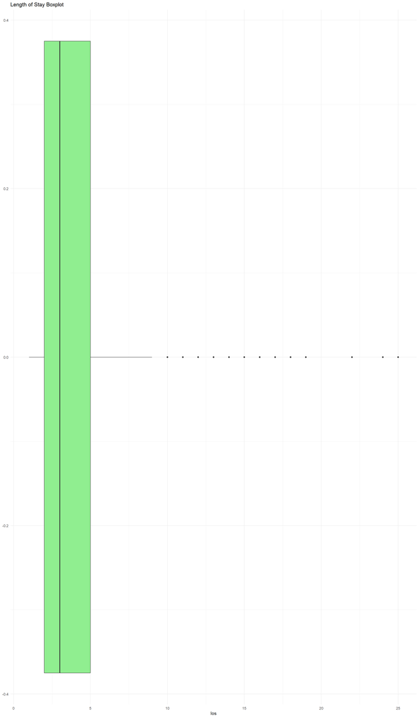

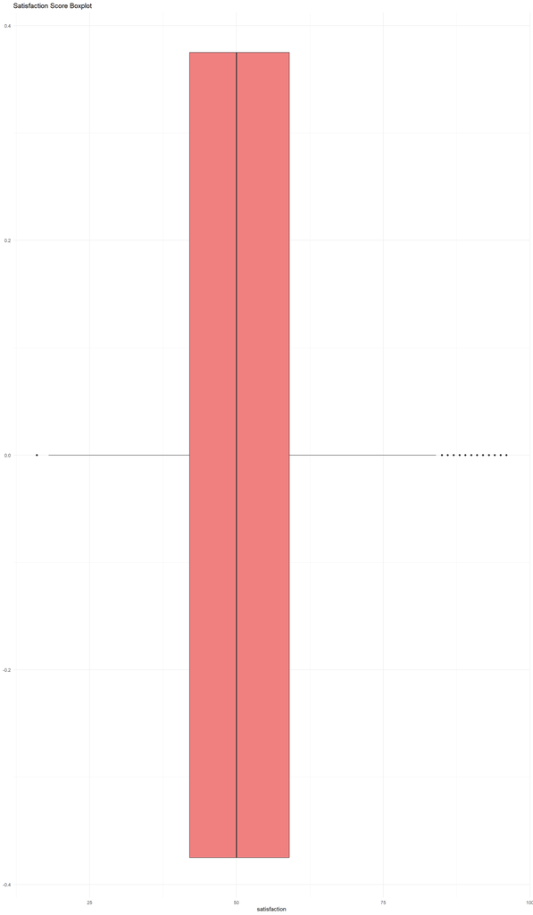

For the Age boxplot, we can see most of patients are between 65-80 years old. Median age is around 70 and the outliers show a few younger patients below 40.

In term of Length of stay, the majority of patients stay in the hospital for short period (2-5 days), with a few patients having longer stays of over 10 days (outliers).

Regarding to satisfaction scores, they are clustered around the middle with a median score of 50, but there are some patients who rated their satisfaction much higher (outliers). It means that the general satisfaction is around 50, however, there are a few patients were much more satisfied than the others.

### 2.1.4 Distribution for Cat varibales

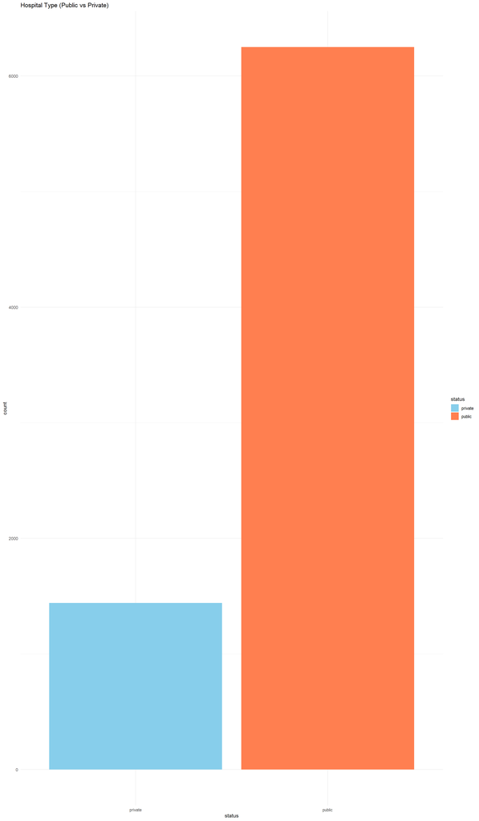

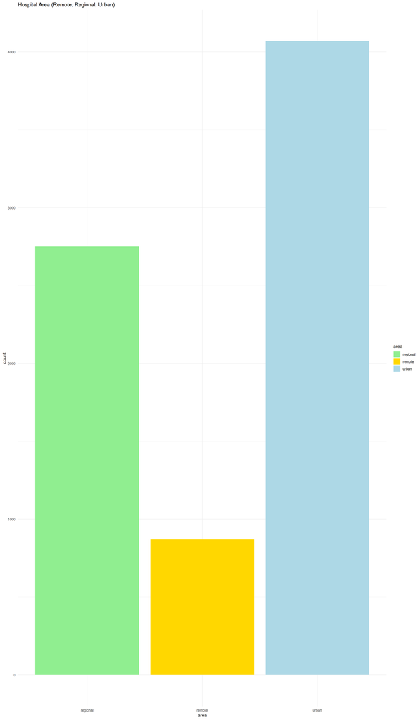

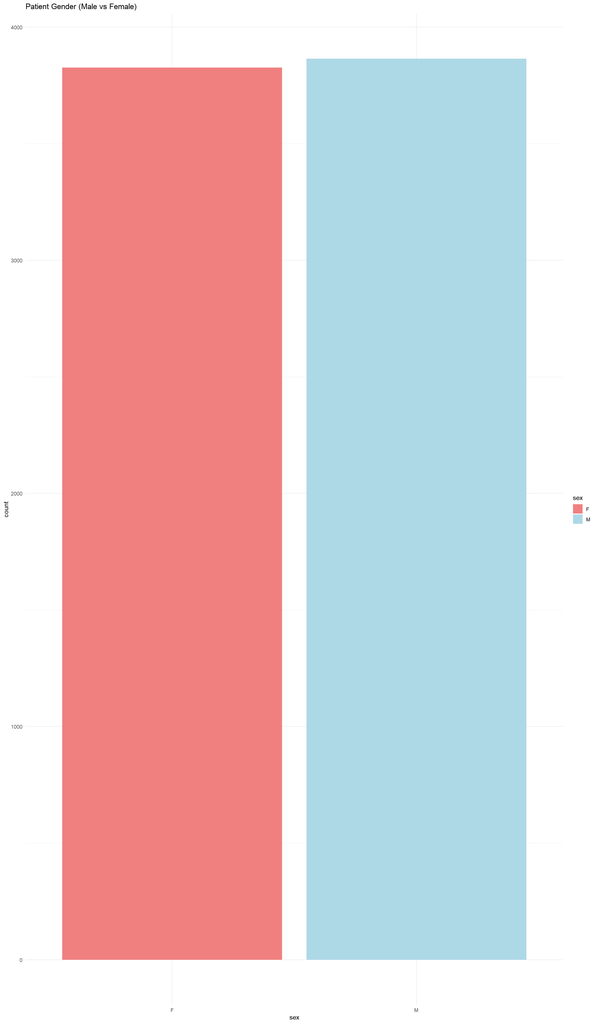

In term of patient gender, there is no difference between male and female patients.

## 2.2 Question 2: Fit a series of multilevel models and select the best-fitting model for the data

### 2.2.1 Model 1 (Empty/Null model)

```
## Linear mixed model fit by REML ['lmerMod']
## Formula: satisfaction ~ (1 | id)
##    Data: hospSatisfaction
##
## REML criterion at convergence: 54448.8
##
## Scaled residuals:
##     Min      1Q  Median      3Q     Max
## -3.3760 -0.7013  0.0180  0.7121  3.2467
##
## Random effects:
##  Groups   Name        Variance Std.Dev.
##  id       (Intercept) 130.19   11.410
##  Residual              67.55    8.219
## Number of obs: 7690, groups:  id, 40
##
## Fixed effects:
##             Estimate Std. Error t value
## (Intercept)   54.898      1.807   30.38
```

```
## Linear mixed-effects model fit by REML
##   Data: hospSatisfaction
##        AIC      BIC    logLik
##   54454.85 54475.69 -27224.42
##
## Random effects:
##  Formula: ~1 | id
##         (Intercept) Residual
## StdDev:    11.40994 8.219176
##
## Fixed effects:  satisfaction ~ 1
##                Value Std.Error   DF t-value p-value
## (Intercept) 54.89806  1.807249 7650 30.3766       0
##
## Standardized Within-Group Residuals:
##         Min          Q1         Med          Q3         Max
## -3.37601225 -0.70130200  0.01801137  0.71205775  3.24674976
##
## Number of Observations: 7690
## Number of Groups: 40
```

### 2.2.2 Model 2 (adding patient-level predictors)

```
## Linear mixed model fit by REML ['lmerMod']
## Formula: satisfaction ~ sex + age + los + readmission + (1 | id)
##    Data: hospSatisfaction
##
## REML criterion at convergence: 49098.4
##
## Scaled residuals:
##     Min      1Q  Median      3Q     Max
## -3.8918 -0.6783  0.0203  0.6802  3.6730
##
## Random effects:
##  Groups   Name        Variance Std.Dev.
##  id       (Intercept) 133.9    11.569
##  Residual              33.5     5.788
## Number of obs: 7690, groups:  id, 40
##
## Fixed effects:
##                 Estimate Std. Error t value
## (Intercept)    33.158035   1.874966  17.685
## sexM           -7.219491   0.132520 -54.479
## age             0.340430   0.005753  59.172
## los            -0.007491   0.024660  -0.304
## readmissionYes  5.435589   0.153738  35.356
##
## Correlation of Fixed Effects:
##             (Intr) sexM   age    los
## sexM        -0.032
## age         -0.205 -0.022
## los         -0.008  0.011 -0.210
## readmissnYs -0.017 -0.005 -0.014  0.006
```

```
## Linear mixed-effects model fit by REML
##   Data: hospSatisfaction
##        AIC      BIC    logLik
##   49112.45 49161.08 -24549.22
##
## Random effects:
##  Formula: ~1 | id
##         (Intercept) Residual
## StdDev:    11.56944 5.787937
##
## Fixed effects:  satisfaction ~ sex + age + los + readmission
##                   Value Std.Error   DF   t-value p-value
## (Intercept)    33.15804 1.8749663 7646  17.68460  0.0000
## sexM           -7.21949 0.1325197 7646 -54.47862  0.0000
## age             0.34043 0.0057533 7646  59.17174  0.0000
## los            -0.00749 0.0246602 7646  -0.30379  0.7613
## readmissionYes  5.43559 0.1537378 7646  35.35624  0.0000
##  Correlation:
##                (Intr) sexM   age    los
## sexM           -0.032
## age            -0.205 -0.022
## los            -0.008  0.011 -0.210
## readmissionYes -0.017 -0.005 -0.014  0.006
##
## Standardized Within-Group Residuals:
##         Min          Q1         Med          Q3         Max
## -3.89175888 -0.67834419  0.02031851  0.68020095  3.67303628
##
## Number of Observations: 7690
## Number of Groups: 40
```

### 2.2.3 Model 3 (adding hospital-level predictors)

```
## Linear mixed model fit by REML ['lmerMod']
## Formula: satisfaction ~ sex + age + los + readmission + status + area +
##     (1 | id)
##    Data: hospSatisfaction
##
## REML criterion at convergence: 49003.4
##
## Scaled residuals:
##     Min      1Q  Median      3Q     Max
## -3.9005 -0.6779  0.0191  0.6795  3.6670
##
## Random effects:
##  Groups   Name        Variance Std.Dev.
##  id       (Intercept) 15.3     3.912
##  Residual             33.5     5.788
## Number of obs: 7690, groups:  id, 40
##
## Fixed effects:
##                  Estimate Std. Error t value
## (Intercept)     39.523083   1.850517  21.358
## sexM            -7.220641   0.132513 -54.490
## age              0.340447   0.005753  59.176
## los             -0.007676   0.024659  -0.311
## readmissionYes   5.435602   0.153732  35.358
## statuspublic   -13.757724   1.531672  -8.982
## arearemote      18.657389   1.674422  11.143
## areaurban       -1.956085   1.516728  -1.290
##
## Correlation of Fixed Effects:
##             (Intr) sexM   age    los    rdmssY sttspb arermt
## sexM        -0.033
## age         -0.209 -0.022
## los         -0.006  0.011 -0.210
## readmissnYs -0.018 -0.005 -0.014  0.006
## statuspublc -0.759  0.001  0.002 -0.002  0.000
## arearemote  -0.548 -0.002  0.001 -0.002  0.002  0.174
## areaurban   -0.620  0.002  0.000 -0.001  0.001  0.212  0.544
```

```
## Linear mixed-effects model fit by REML
##   Data: hospSatisfaction
##        AIC     BIC    logLik
##   49023.44 49092.9 -24501.72
##
## Random effects:
##  Formula: ~1 | id
##         (Intercept) Residual
## StdDev:    3.911879 5.787896
##
## Fixed effects:  satisfaction ~ sex + age + los + readmission + status + area
##                    Value Std.Error   DF   t-value p-value
## (Intercept)     39.52308 1.8505165 7646  21.35787  0.0000
## sexM            -7.22064 0.1325133 7646 -54.48995  0.0000
## age              0.34045 0.0057531 7646  59.17649  0.0000
## los             -0.00768 0.0246594 7646  -0.31127  0.7556
## readmissionYes   5.43560 0.1537323 7646  35.35758  0.0000
## statuspublic   -13.75772 1.5316716   36  -8.98216  0.0000
## arearemote      18.65739 1.6744216   36  11.14259  0.0000
## areaurban       -1.95608 1.5167280   36  -1.28967  0.2054
##  Correlation:
##                (Intr) sexM   age    los    rdmssY sttspb arermt
## sexM           -0.033
## age            -0.209 -0.022
## los            -0.006  0.011 -0.210
## readmissionYes -0.018 -0.005 -0.014  0.006
## statuspublic   -0.759  0.001  0.002 -0.002  0.000
## arearemote     -0.548 -0.002  0.001 -0.002  0.002  0.174
## areaurban      -0.620  0.002  0.000 -0.001  0.001  0.212  0.544
##
## Standardized Within-Group Residuals:
##         Min          Q1         Med          Q3         Max
## -3.90048090 -0.67794457  0.01909772  0.67948585  3.66700519
##
## Number of Observations: 7690
## Number of Groups: 40
```

### 2.2.4 Model 4 (Random slopes model)

```
## boundary (singular) fit: see help('isSingular')
```

```
## Linear mixed model fit by REML ['lmerMod']
## Formula: satisfaction ~ sex + age + los + readmission + status + area +
##     (los | id)
##    Data: hospSatisfaction
##
## REML criterion at convergence: 49003.4
##
## Scaled residuals:
##     Min      1Q  Median      3Q     Max
## -3.9003 -0.6801  0.0179  0.6798  3.6702
##
## Random effects:
##  Groups   Name        Variance  Std.Dev. Corr
##  id       (Intercept) 1.510e+01 3.885719
##           los         4.124e-05 0.006422 1.00
##  Residual             3.350e+01 5.787868
## Number of obs: 7690, groups:  id, 40
##
## Fixed effects:
##                  Estimate Std. Error t value
## (Intercept)     39.461818   1.847891  21.355
## sexM            -7.221109   0.132512 -54.494
## age              0.340465   0.005753  59.180
## los             -0.006657   0.024684  -0.270
## readmissionYes   5.434822   0.153732  35.353
## statuspublic   -13.748120   1.530388  -8.983
## arearemote      18.687916   1.673411  11.168
## areaurban       -1.860613   1.515016  -1.228
##
## Correlation of Fixed Effects:
##             (Intr) sexM   age    los    rdmssY sttspb arermt
## sexM        -0.032
## age         -0.210 -0.022
## los          0.008  0.011 -0.210
## readmissnYs -0.018 -0.005 -0.014  0.006
## statuspublc -0.760  0.000  0.002  0.002  0.000
## arearemote  -0.547 -0.002  0.002 -0.014  0.002  0.174
## areaurban   -0.620  0.001  0.000  0.000  0.002  0.212  0.544
## optimizer (nloptwrap) convergence code: 0 (OK)
## boundary (singular) fit: see help('isSingular')
```

```
## Linear mixed-effects model fit by REML
##   Data: hospSatisfaction
##        AIC     BIC    logLik
##   49027.44 49110.8 -24501.72
##
## Random effects:
##  Formula: ~los | id
##  Structure: General positive-definite, Log-Cholesky parametrization
##             StdDev      Corr
## (Intercept) 3.911879819 (Intr)
## los         0.000210373 0
## Residual    5.787896077
##
## Fixed effects:  satisfaction ~ sex + age + los + readmission + status + area
##                    Value Std.Error   DF   t-value p-value
## (Intercept)     39.52308 1.8505168 7646  21.35786  0.0000
## sexM            -7.22064 0.1325133 7646 -54.48995  0.0000
## age              0.34045 0.0057531 7646  59.17649  0.0000
## los             -0.00768 0.0246595 7646  -0.31127  0.7556
## readmissionYes   5.43560 0.1537323 7646  35.35758  0.0000
## statuspublic   -13.75772 1.5316719   36  -8.98216  0.0000
## arearemote      18.65739 1.6744219   36  11.14259  0.0000
## areaurban       -1.95608 1.5167282   36  -1.28967  0.2054
##  Correlation:
##                (Intr) sexM   age    los    rdmssY sttspb arermt
## sexM           -0.033
## age            -0.209 -0.022
## los            -0.006  0.011 -0.210
## readmissionYes -0.018 -0.005 -0.014  0.006
## statuspublic   -0.759  0.001  0.002 -0.002  0.000
## arearemote     -0.548 -0.002  0.001 -0.002  0.002  0.174
## areaurban      -0.620  0.002  0.000 -0.001  0.001  0.212  0.544
##
## Standardized Within-Group Residuals:
##         Min          Q1         Med          Q3         Max
## -3.90048094 -0.67794443  0.01909784  0.67948542  3.66700515
##
## Number of Observations: 7690
## Number of Groups: 40
```

### 2.2.5 Compare models

|  | df | AIC |
| --- | --- | --- |
| model_1 | 3 | 54454.85 |
| model_2 | 7 | 49112.45 |
| model_3 | 10 | 49023.44 |
| model_4 | 12 | 49027.37 |

|  | df | BIC |
| --- | --- | --- |
| model_1 | 3 | 54475.69 |
| model_2 | 7 | 49161.08 |
| model_3 | 10 | 49092.92 |
| model_4 | 12 | 49110.74 |

|  | df | AIC |
| --- | --- | --- |
| model_11 | 3 | 54454.85 |
| model_22 | 7 | 49112.45 |
| model_33 | 10 | 49023.44 |
| model_44 | 12 | 49027.44 |

|  | df | BIC |
| --- | --- | --- |
| model_11 | 3 | 54475.69 |
| model_22 | 7 | 49161.08 |
| model_33 | 10 | 49092.90 |
| model_44 | 12 | 49110.80 |

Base on the AIC and BIC for the list of models above, I will choose the model 3 (or model 33 for nlme package). Because it has the lowest AIC and BIC compare to other models.

There are a few different between ‘lme4’ and ‘nlme’ package, so for this question, I tried both to see which model I will choose, but the result is similar which is model_3 (lme4) or model_33 (nlme).

```
## Computing profile confidence intervals ...
```

```
##                       2.5 %       97.5 %
## .sig01           3.01387412   4.71047693
## .sigma           5.69588379   5.87928356
## (Intercept)     35.99648485  43.05001310
## sexM            -7.48037595  -6.96100758
## age              0.32917380   0.35172230
## los             -0.05602451   0.04062536
## readmissionYes   5.13426504   5.73679982
## statuspublic   -16.67631618 -10.83954757
## arearemote      15.46693061  21.84774661
## areaurban       -4.84590408   0.93373346
```

```
## Approximate 95% confidence intervals
##
##  Fixed effects:
##                       lower          est.        upper
## (Intercept)     35.89556335  39.523083279  43.15060321
## sexM            -7.48040286  -7.220640542  -6.96087822
## age              0.32916948   0.340447099   0.35172471
## los             -0.05601502  -0.007675746   0.04066353
## readmissionYes   5.13424420   5.435601693   5.73695919
## statuspublic   -16.86409800 -13.757723945 -10.65134989
## arearemote      15.26150411  18.657388602  22.05327309
## areaurban       -5.03215170  -1.956084782   1.11998214
##
##  Random Effects:
##   Level: id
##                   lower     est.    upper
## sd((Intercept)) 3.09581 3.911879 4.943068
##
##  Within-group standard error:
##    lower     est.    upper
## 5.696885 5.787896 5.880361
```

## 2.3 Question 3: For your chosen model, check the model validity and communicate the model results using appropriate visualisations

### 2.3.1 Check model validity

#### 2.3.1.1 Residual Diagnostic

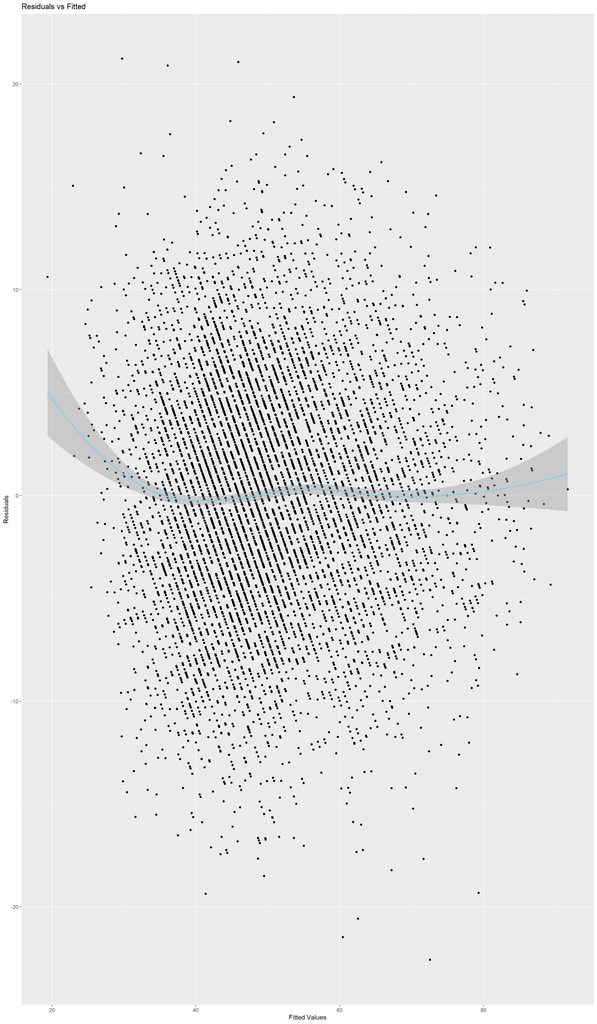

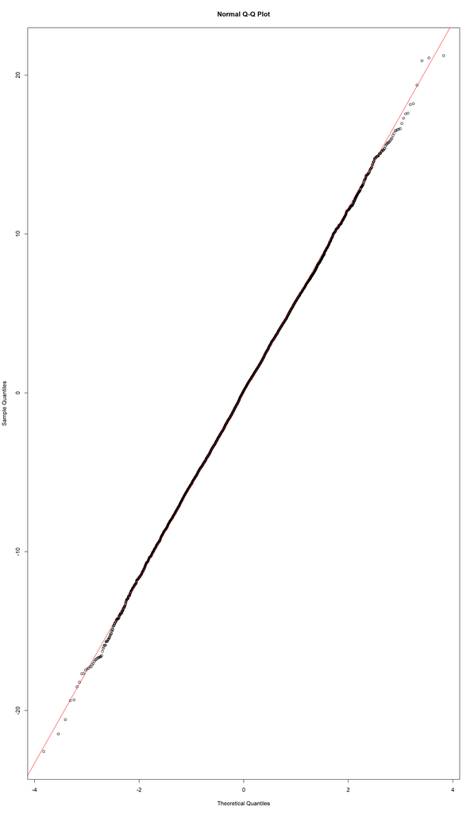

The residuals vs fitted and the qq plot above show that the residuals are normally distributed with fairly constant variance, even though there is a slight nonlinearity. In general, the model’s assumptions are largely met with no major violations.

#### 2.3.1.2 Random Effect Diagnostic

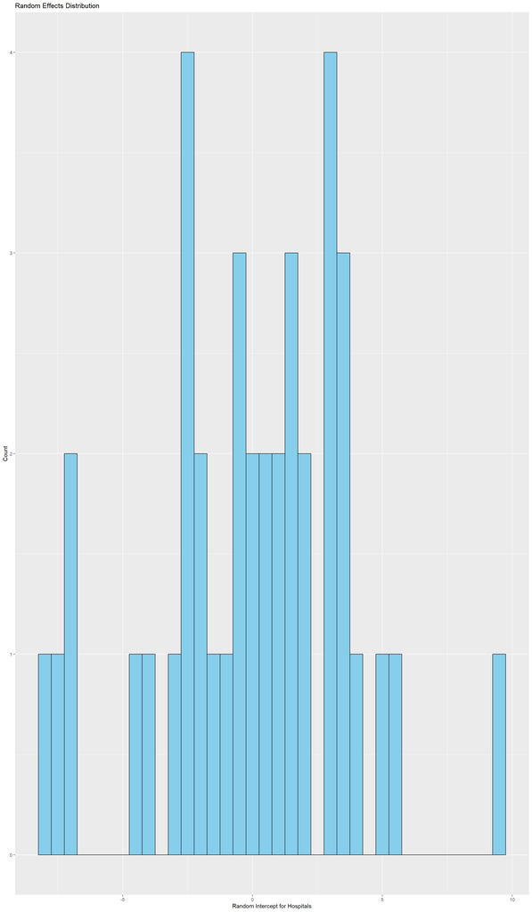

The random effects distribution shows that many hospitals are clustered around the overall average satisfaction score (0). However, there are a few hospitals have extreme random effect (way above 5) means they have much higher satisfaction scores than the average and some hospitals have low random effects (below -5) indicating that they have much lower satisfaction score than the average.

#### 2.3.1.3 Linearity

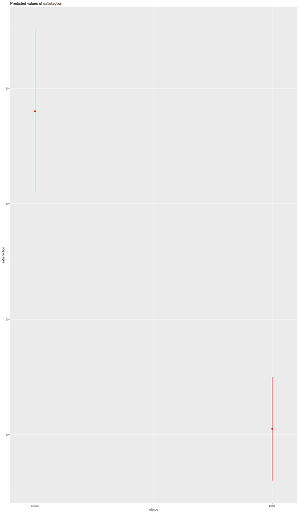

By looking at the graph above, we easily to see that private hospitals have significantly higher predicted patient satisfaction compared to public ones.

### 2.3.2 Model results using visualizations

#### 2.3.2.1 Fixed Effects Coefficients

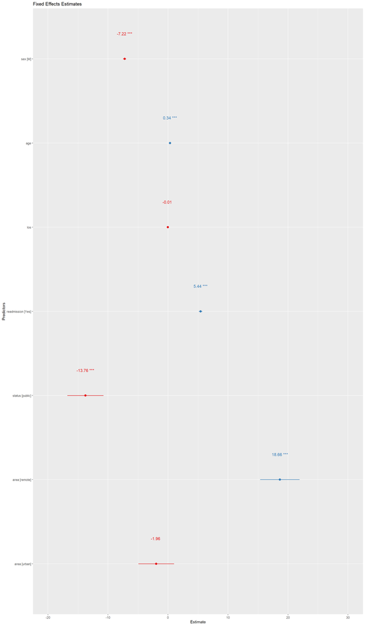

Looking at the fixed effects estimates plot above, we can see that only LOS and Urban is not statistically significant (there is no stars next to the figure) while the rest are statistically significant. Fixed effects estimates for Age readmission and area(remote) indicate that patient have higher satisfaction (Older have higher satisfaction than younger ones, readdmission patients have higher satisfaction than those who were not readmiited, patients in remote hospitals report significantly higher satisfaction compared to those in regional hospitals). In term of lower satisfaction, patients in public hospitals are predicted to have the most significant lower satisfaction score compared to patients in private hospitals. Next measure is sex, male patients are predicted to have lower satisfaction score than female patients.

#### 2.3.2.2 Random Effect Plot

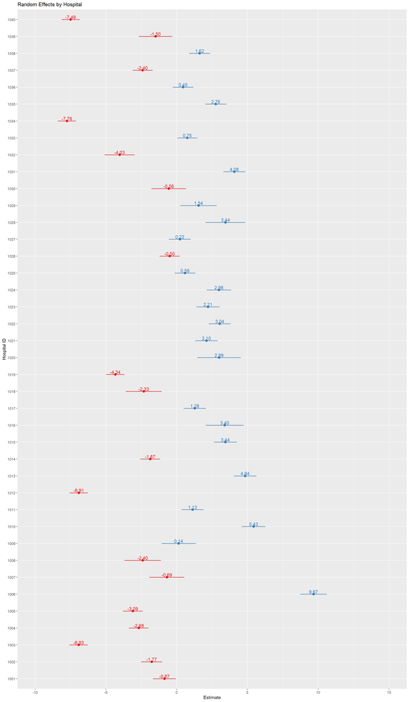

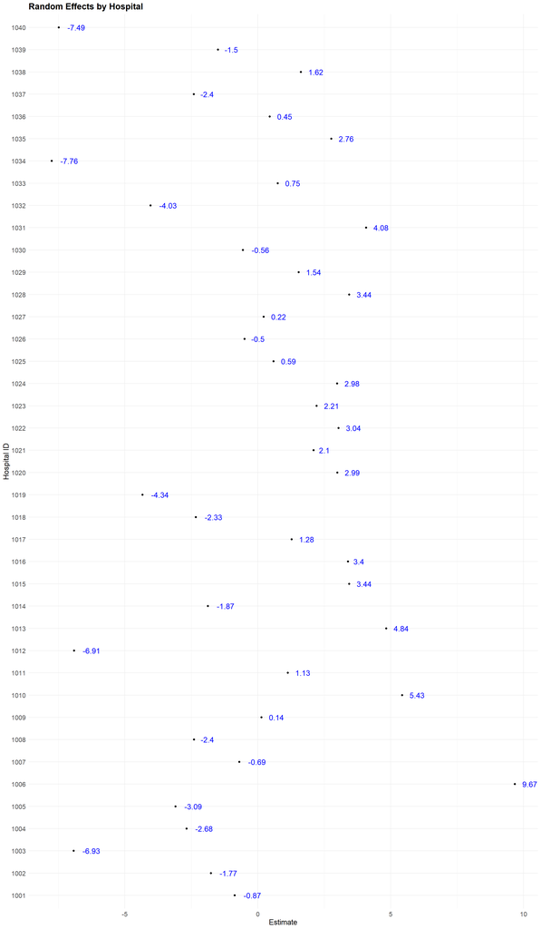

With those 2 plot of random effects by hospital above, there is a wide range of random intercepts across hospitals, indicate that satisfaction varies between hospitals considerably. Some perform much better than average, while others perform worse.

#### 2.3.2.3 Predicted vs observed values

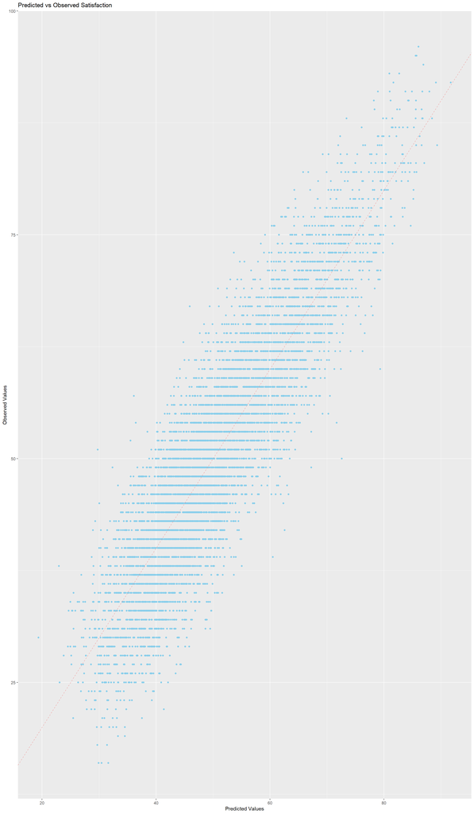

The plot above reveals that the model is reasonably accurate. Most of the dots are clustered around the identity line. Except some points at extremes, the model captures quite well the general trend of the data.

## 2.4 Question 4: For your chosen model, provide a written interpretation of all of the model parameters

| effect | group | term | estimate | std.error | statistic |
| --- | --- | --- | --- | --- | --- |
| fixed | NA | (Intercept) | 39.523083277 | 1.85051665 | 21.357864 |
| fixed | NA | sexM | -7.220640542 | 0.13251325 | -54.489950 |
| fixed | NA | age | 0.340447099 | 0.00575308 | 59.176490 |
| fixed | NA | los | -0.007675746 | 0.02465944 | -0.311270 |
| fixed | NA | readmissionYes | 5.435601693 | 0.15373231 | 35.357575 |
| fixed | NA | statuspublic | -13.757723941 | 1.53167177 | -8.982162 |
| fixed | NA | arearemote | 18.657388603 | 1.67442179 | 11.142586 |
| fixed | NA | areaurban | -1.956084782 | 1.51672811 | -1.289674 |
| ran_pars | id | sd__(Intercept) | 3.911879744 | NA | NA |
| ran_pars | Residual | sd__Observation | 5.787896103 | NA | NA |

### 2.4.1 Chosen Model: Model 3

Linear mixed model fit by REML [‘lmerMod’] Formula: satisfaction ~ sex + age + los + readmission + status + area + (1 | id) Data: hospSatisfaction

REML criterion at convergence: 49003.4

Scaled residuals: Min 1Q Median 3Q Max -3.9005 -0.6779 0.0191 0.6795 3.6670

Random effects: Groups Name Variance Std.Dev. id (Intercept) 15.3 3.912  
Residual 33.5 5.788  
Number of obs: 7690, groups: id, 40

Fixed effects: Estimate Std. Error t value (Intercept) 39.523083 1.850517 21.358 sexM -7.220641 0.132513 -54.490 age 0.340447 0.005753 59.176 los -0.007676 0.024659 -0.311 readmissionYes 5.435602 0.153732 35.358 statuspublic -13.757724 1.531672 -8.982 arearemote 18.657389 1.674422 11.143 areaurban -1.956085 1.516728 -1.290

Correlation of Fixed Effects: (Intr) sexM age los rdmssY sttspb arermt sexM -0.033  
age -0.209 -0.022  
los -0.006 0.011 -0.210  
readmissnYs -0.018 -0.005 -0.014 0.006  
statuspublic-0.759 0.001 0.002 -0.002 0.000  
arearemote -0.548 -0.002 0.001 -0.002 0.002 0.174  
areaurban -0.620 0.002 0.000 -0.001 0.001 0.212 0.544

In summary, sex, age, readmission status, status (public/private), and remote area are significant predictors which play meaningful role to impact satisfaction in patients.